# Analisis espacial Boston Housing

## Pruebas de normalidad

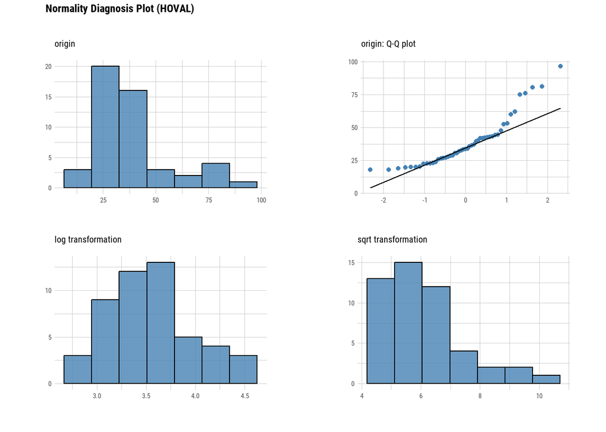

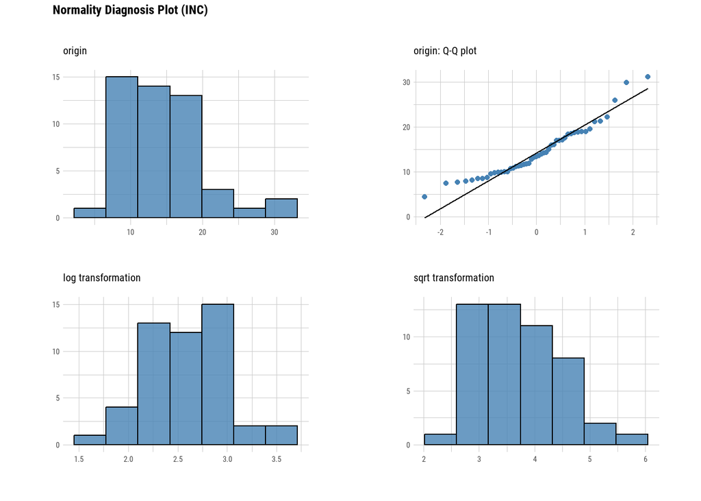

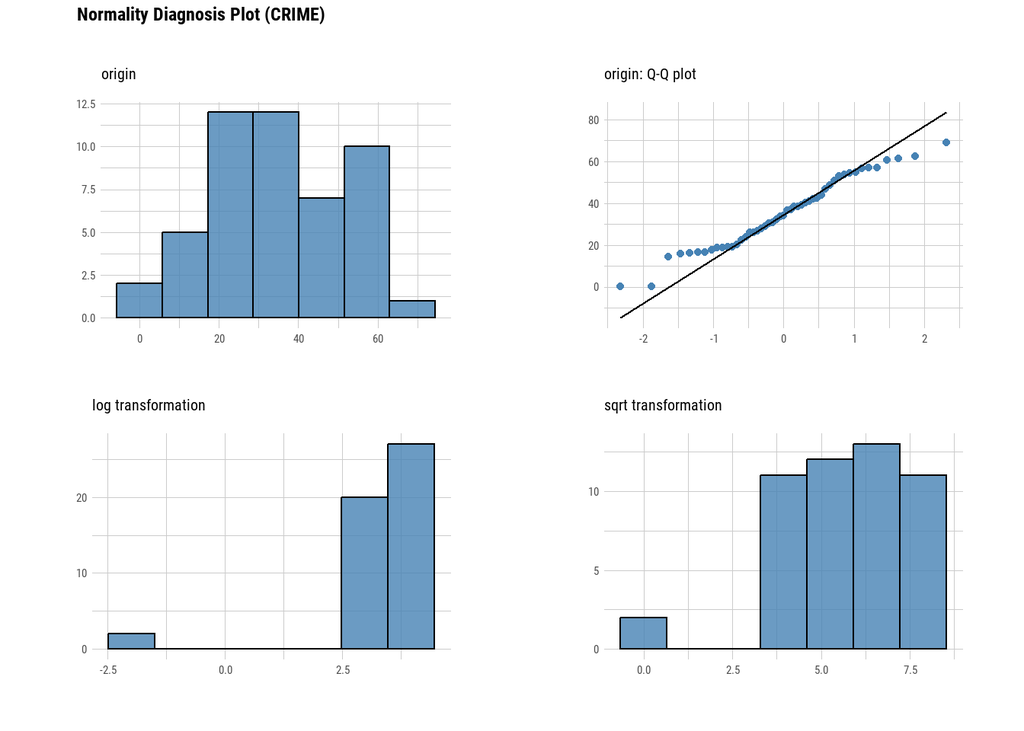

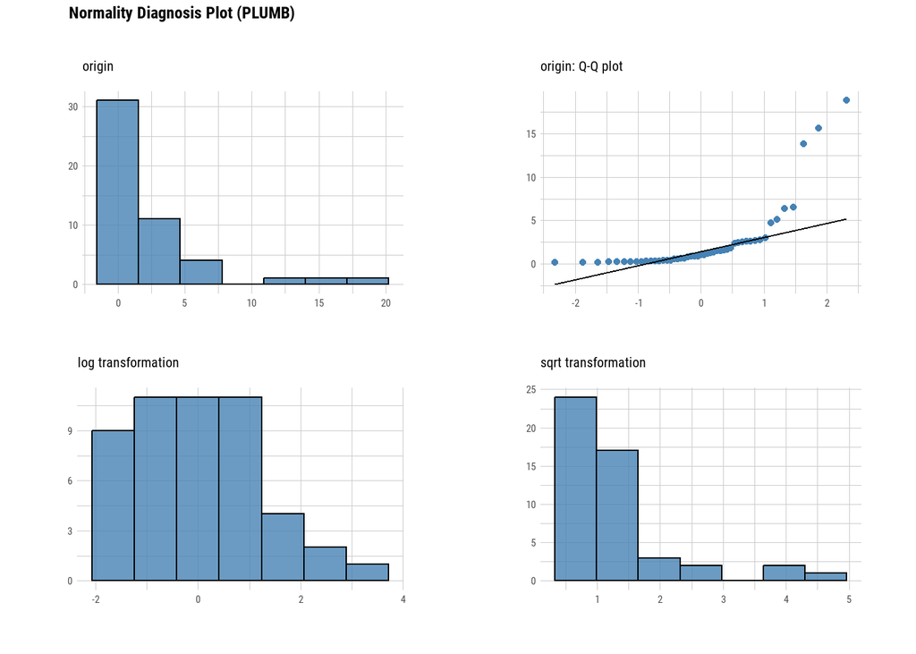

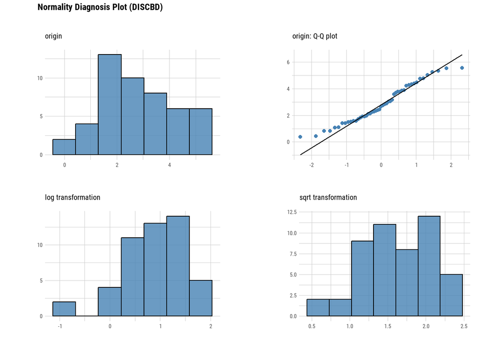

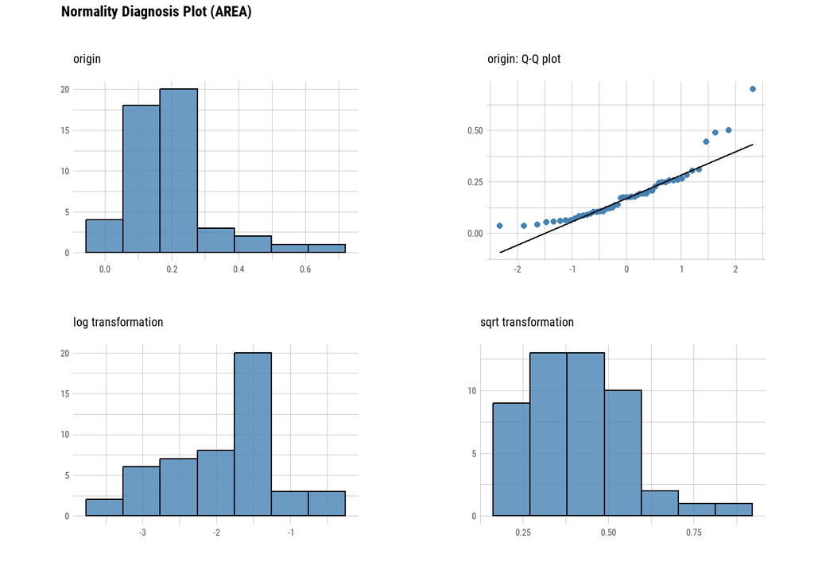

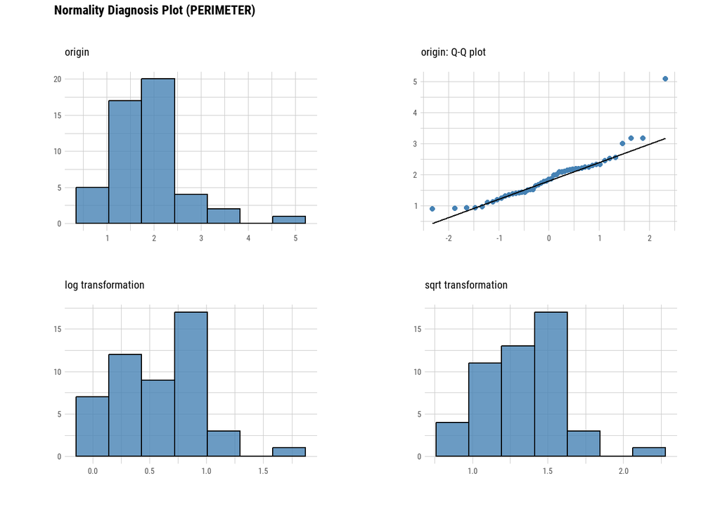

Se hara una transformacion a la variable dependiente HOVAL para normalizarla, al igual que plumb y area, ya que presentan un mayor sesgo

```r
columbus$HOVAL = log(columbus$HOVAL)
columbus$PLUMB = log(columbus$PLUMB)
columbus$AREA = log(columbus$AREA)
```

## Boxplots

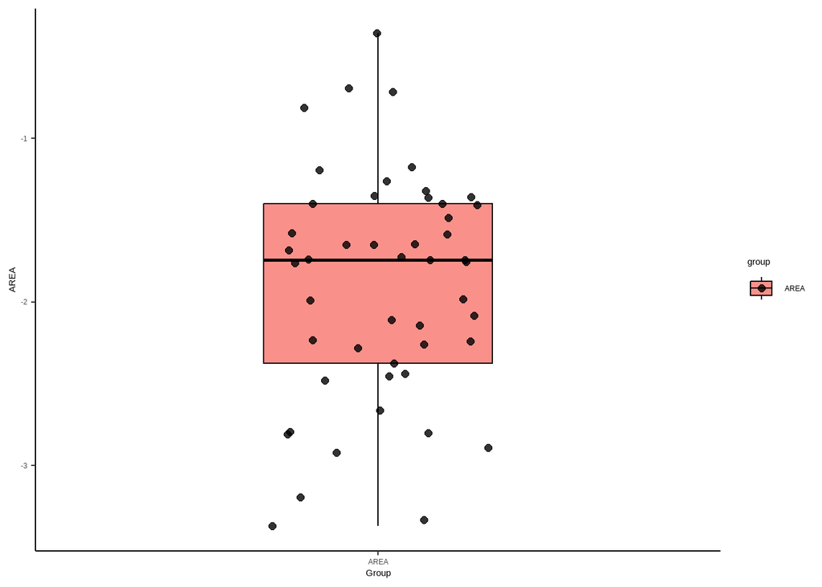

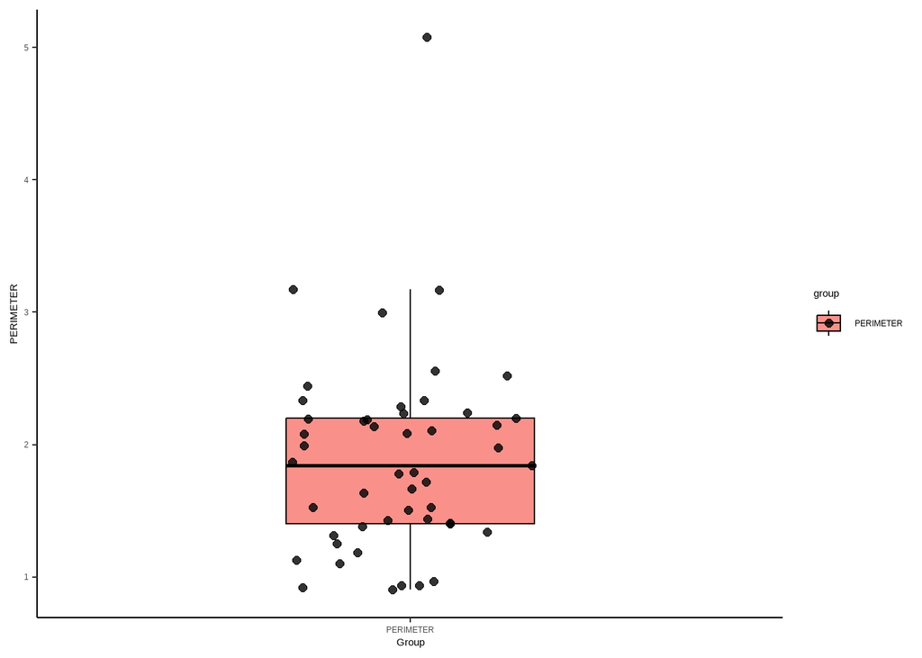

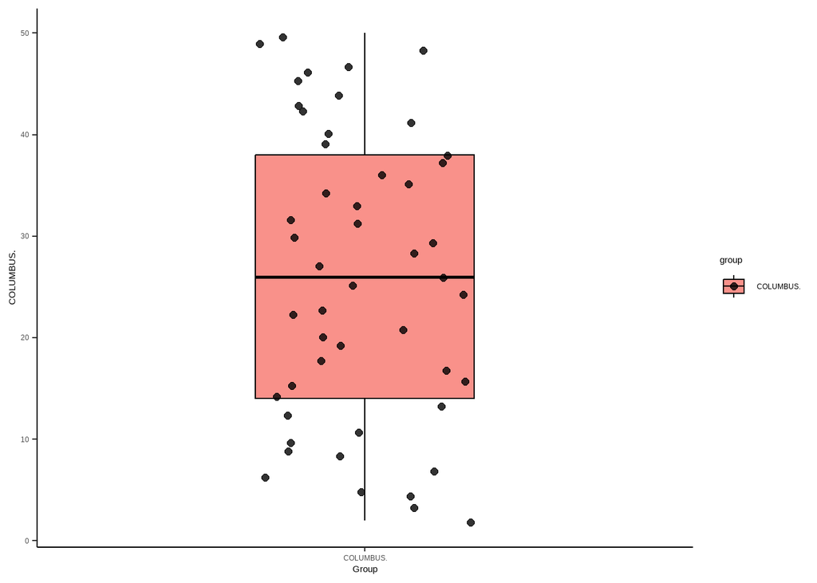

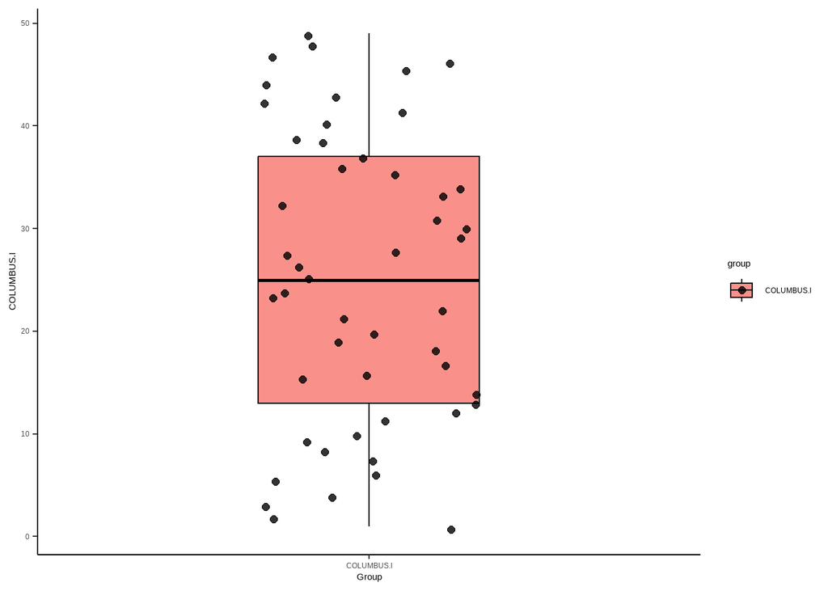

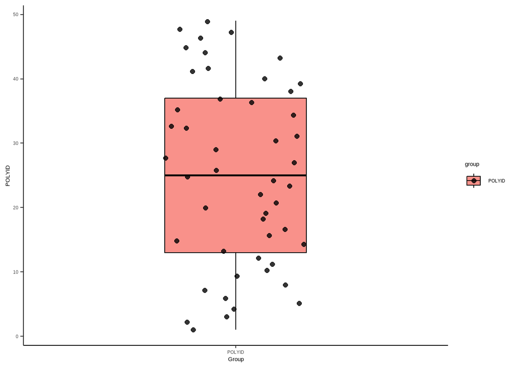

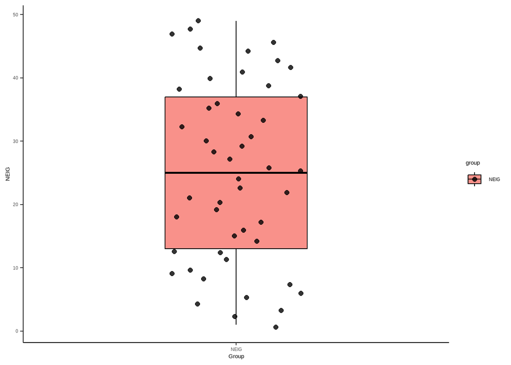

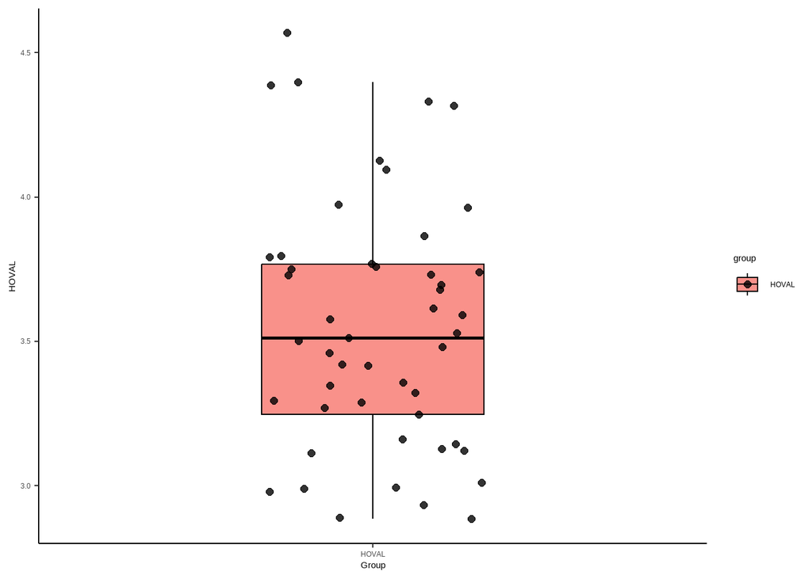

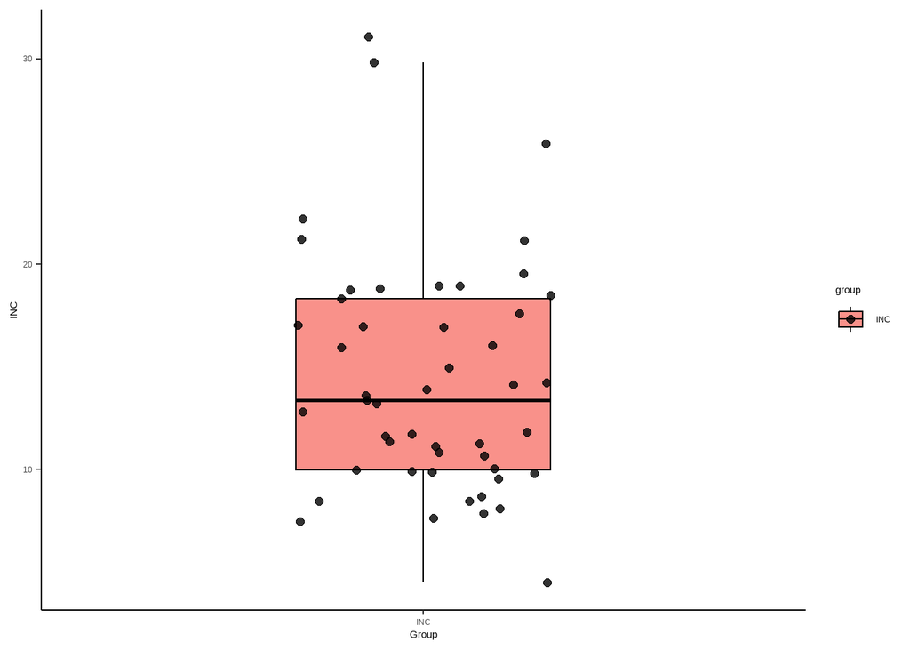

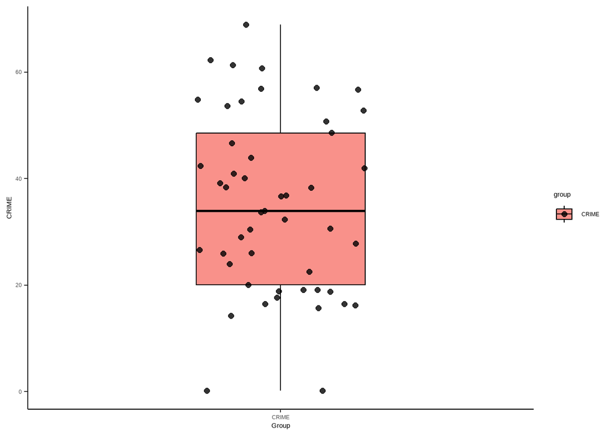

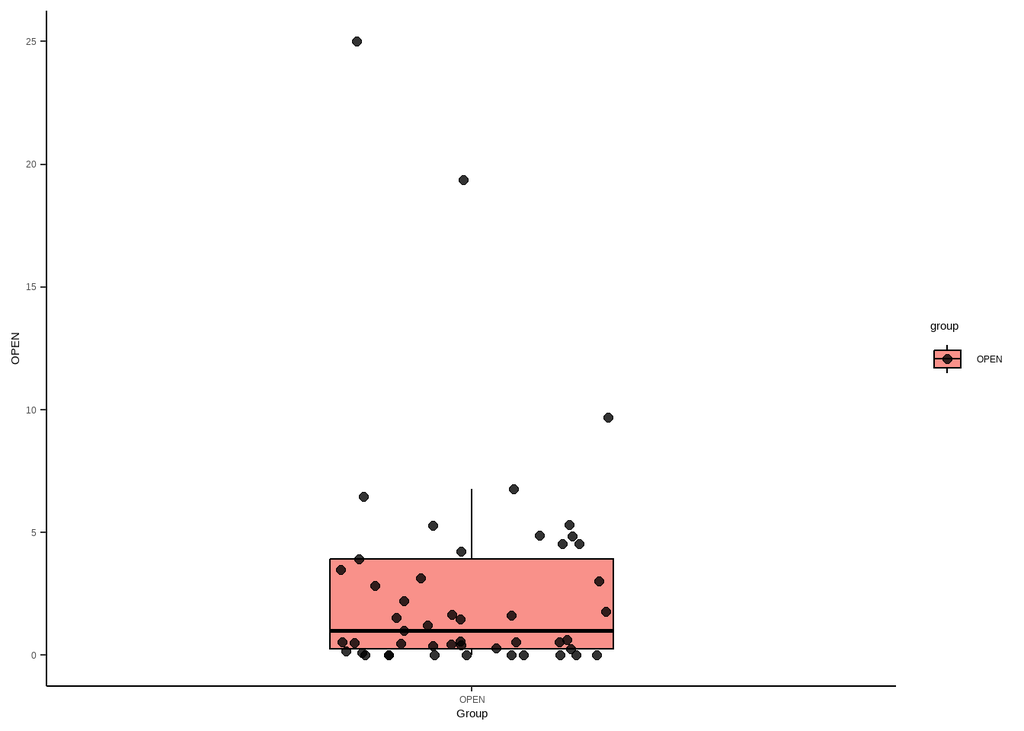

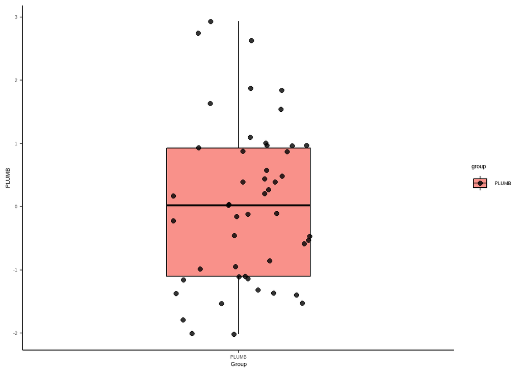

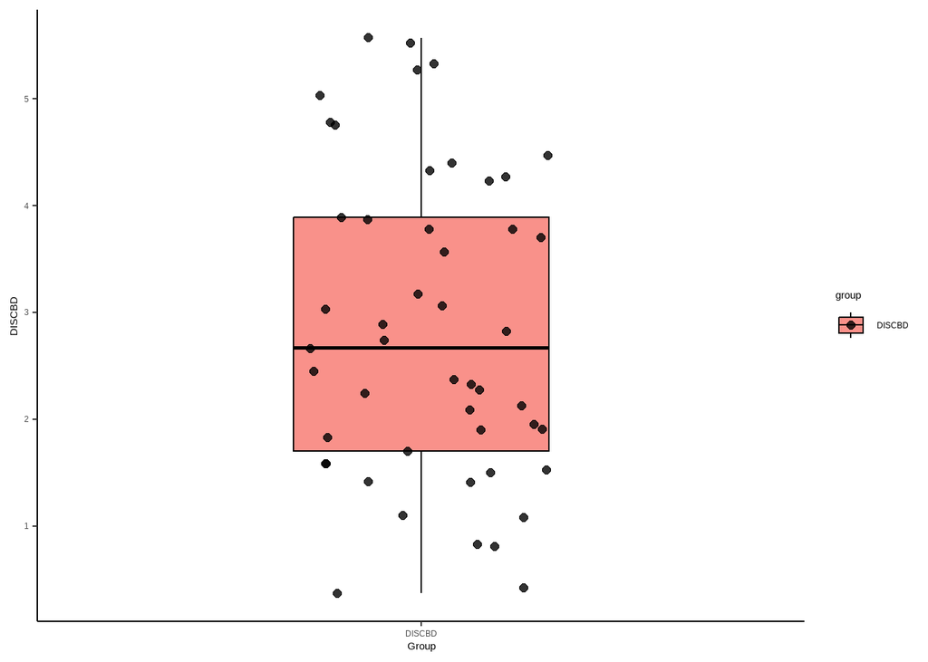

[8 more figures not shown]

```r
cute_boxplots <- function(data) {
  for (col in colnames(data)) {
    plot_data <- data.frame(group = col, value = data[[col]])
    p <- ggplot(plot_data, aes(x = group, y = value, fill = group)) +
      geom_boxplot(alpha = 0.8, outlier.shape = NA, width = 0.4, color = "black") +
      geom_jitter(width = 0.2, size = 2, alpha = 0.8) +
      scale_fill_manual(values = c("#F8766D", "#00BFC4", "#7CAE00")) +
      labs(x = "Group", y = col) +
      theme_classic()
    print(p)
  }
}

cute_boxplots(columbus)
```

## Matriz de correlación:

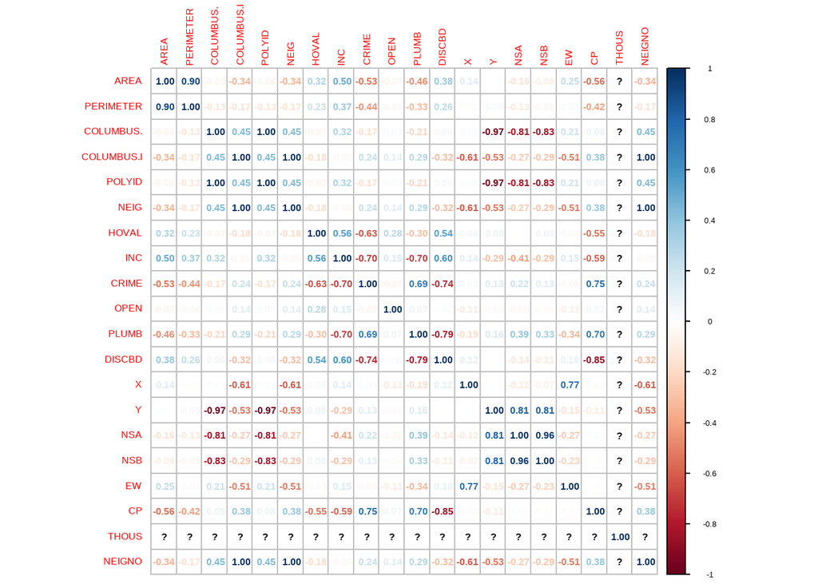

```r
cor_matrix <- cor(columbus)
corrplot(cor_matrix, method = "number")
```

# Análisis Exploratorio Espacial de los Datos (ESDA)

## Autocorrelacion espacial global en variables de interes

### Metodo Queen

```r
swm_queen <- poly2nb(columbus_shp, queen = TRUE)
```

### Metodo Rook

```r
swm_rook <- poly2nb(columbus_shp, queen = FALSE)
```

```r
rswm_queen <- nb2listw(swm_queen, style = "W", zero.policy = TRUE)
rswm_rook  <- nb2listw(swm_rook, style = "W", zero.policy = TRUE)
```

### Global Moran test

```r
moran.test(columbus$HOVAL, listw = rswm_queen, zero.policy = TRUE, na.action = na.omit)
```

```
##
##  Moran I test under randomisation
##
## data:  columbus$HOVAL
## weights: rswm_queen
##
## Moran I statistic standard deviate = 2.9453, p-value = 0.001613
## alternative hypothesis: greater
## sample estimates:
## Moran I statistic       Expectation          Variance
##       0.252777699      -0.020833333       0.008629742
```

Podemos encontrar auto correlacion global con la variable de Hoval el p value es menor a .05 por lo tanto se rechaza la hipotesis nula y se acepta la hipotesis alternativa de que existe autocorrelacion espacial

```r
moran.test(columbus$CRIME, listw = rswm_queen, zero.policy = TRUE, na.action = na.omit)
```

```
##
##  Moran I test under randomisation
##
## data:  columbus$CRIME
## weights: rswm_queen
##
## Moran I statistic standard deviate = 5.5894, p-value = 1.139e-08
## alternative hypothesis: greater
## sample estimates:
## Moran I statistic       Expectation          Variance
##       0.500188557      -0.020833333       0.008689289
```

Podemos encontrar auto correlacion global con la variable de CRIME el p value es menor a .05 por lo tanto se rechaza la hipotesis nula y se acepta la hipotesis alternativa de que existe autocorrelacion espacial

```r
moran.test(columbus$PLUMB, listw = rswm_queen, zero.policy = TRUE, na.action = na.omit)
```

```
##
##  Moran I test under randomisation
##
## data:  columbus$PLUMB
## weights: rswm_queen
##
## Moran I statistic standard deviate = 7.5613, p-value = 1.996e-14
## alternative hypothesis: greater
## sample estimates:
## Moran I statistic       Expectation          Variance
##       0.681818585      -0.020833333       0.008635588
```

```r
moran.test(columbus$DISCBD, listw = rswm_queen, zero.policy = TRUE, na.action = na.omit)
```

```
##
##  Moran I test under randomisation
##
## data:  columbus$DISCBD
## weights: rswm_queen
##
## Moran I statistic standard deviate = 8.7904, p-value < 2.2e-16
## alternative hypothesis: greater
## sample estimates:
## Moran I statistic       Expectation          Variance
##       0.800562617      -0.020833333       0.008731396
```

Podemos encontrar auto correlacion global con la variable de DISCBD el p value es menor a .05 por lo tanto se rechaza la hipotesis nula y se acepta la hipotesis alternativa de que existe autocorrelacion espacial

```r
moran.test(columbus$INC, listw = rswm_queen, zero.policy = TRUE, na.action = na.omit)
```

```
##
##  Moran I test under randomisation
##
## data:  columbus$INC
## weights: rswm_queen
##
## Moran I statistic standard deviate = 4.7645, p-value = 9.467e-07
## alternative hypothesis: greater
## sample estimates:
## Moran I statistic       Expectation          Variance
##       0.415628778      -0.020833333       0.008391926
```

Podemos encontrar auto correlacion global con la variable de INC el p value es menor a .05 por lo tanto se rechaza la hipotesis nula y se acepta la hipotesis alternativa de que existe autocorrelacion espacial